# Cyclistic Bike-Share Case Study

Udoh Chioma Lilian

2026-01-28

## 1. Business Problem

Cyclistic, a bike-share company in Chicago, aims to increase the number of annual memberships, as membership growth is essential for the company’s long-term profitability and sustainability. However, to achieve this goal, the company must first understand how casual riders(customers who purchase single-ride or full-day passes) and annual members(customers who subscribe annually) use Cyclistic bikes differently.

## 2. Business Task

As a junior data analyst working with the marketing analytics team at Cyclistic, the objective of this project is to analyze user behaviour and identify behavioral differences between casual riders and annual members. The goal is to help the marketing team develop effective strategies to drive conversion.

The final recommendations will be supported by clear data analysis and professional visualizations to ensure they are actionable and persuasive enough to gain approval from Cyclistic executives.

## 3. Data Source Description and Credibility

This case study uses [Divvy 2019 Q1](https://docs.google.com/spreadsheets/u/0/d/1HyGxbpi5Xad5ARKYb5CQL57LrhR2t_KwCt1CRXus5As/edit) and [Divvy 2020 Q1](https://docs.google.com/spreadsheets/u/0/d/1Y92ILGP-9Wyq418FYuVt14smYzt33G3-T8SoJMCo_UM/edit) datasets, provided by Lyft Bikes and Scooters, LLC (“bikeshare”), a bike-share company operating in Chicago. The data is made available under a public [license](https://divvybikes.com/data-license-agreement) by Motivate International Inc., granting permission to access, analyze, and use the data for lawful purposes.

The datasets are structured in Excel format with rows representing individual trips and columns describing trip attributes. For the purpose of this case study, the datasets are appropriate, reliable and comprehensive, containing all necessary variables required for this analysis. Although the data is not fully current, it is appropriate for identifying usage patterns and behavioral differences between rider types.

Personally identifiable information has been removed, ensuring rider privacy. The data was handled securely on a password-protected device and used strictly for analytical purposes.

## 4. Data Cleaning and Preparation

### 4.1 Cleaning Divvy 2019 Q1 Data

cleaning steps included:

- Checking and confirming absence of duplicate `trip_id` values
- Standardizing column names to lowercase with no spaces
- Removing rows with missing values
- Resolving inconsistent station name suffixes (e.g., “Place” to “Pl”)
- Removing leading and trailing whitespace across all entries
- Removing asterisks present in some street address entries across all addresses
- Renaming columns for consistency with 2020 data
- Validating latitude and longitude ranges
- Recalculating trip duration in seconds using start and end times

Trips with incorrect or inconsistent duration values were corrected using calculated durations.

### 4.2 Cleaning Divvy 2020 Q1 Data

Cleaning steps mirrored the 2019 process and additionally included:

- Renaming columns to align with the 2019 schema
- Removing unnecessary columns to enable merging
- Creating a calculated trip duration field

### 4.3 Data Merging and Filtering

The cleaned 2019 and 2020 datasets were merged into a single dataset. User types were standardized as “Casual” and “Member”. Additional cleaning included:

- Creating start and end day of the week columns
- Rearranging tripduration_seconds field to identify any anomalies that could exist
- Removing negative trip duration
- Excluding trips shorter than 60 seconds, as they are likely not genuine bike trips
- Removing trips longer than 24 hours (86,400 seconds), as they likely represent data errors or bike maintenance trips, not typical rider behavior.

Only 1.048% of the total data was removed, ensuring minimal data loss while improving data quality. I now rearranged my dataset so that related fields are positioned close together for better readability and logical flow. Below is a sample of the cleaned dataset:

|  | trip_id | start_time | end_time | tripduration_seconds | start_day_of_the_week | end_day_of_the_week | start_station_id | start_station_name | end_station_id | end_station_name | usertype |
| --- | --- | --- | --- | --- | --- | --- | --- | --- | --- | --- | --- |
| 1 | 21742443 | 2019-01-01 0:04:37 | 2019-01-01 0:11:07 | 390 | Tue | Tue | 199 | Wabash Ave &amp; Grand Ave | 84 | Milwaukee Ave &amp; Grand Ave | Member |
| 2 | 21742444 | 2019-01-01 0:08:13 | 2019-01-01 0:15:34 | 441 | Tue | Tue | 44 | State St &amp; Randolph St | 624 | Dearborn St &amp; Van Buren St | Member |
| 3 | 21742445 | 2019-01-01 0:13:23 | 2019-01-01 0:27:12 | 829 | Tue | Tue | 15 | Racine Ave &amp; 18th St | 644 | Western Ave &amp; Fillmore St | Member |
| 4 | 21742446 | 2019-01-01 0:13:45 | 2019-01-01 0:43:28 | 1783 | Tue | Tue | 123 | California Ave &amp; Milwaukee Ave | 176 | Clark St &amp; Elm St | Member |
| 5 | 21742447 | 2019-01-01 0:14:52 | 2019-01-01 0:20:56 | 364 | Tue | Tue | 173 | Mies Van Der Rohe Way &amp; Chicago Ave | 35 | Streeter Dr &amp; Grand Ave | Member |
| 6 | 21742448 | 2019-01-01 0:15:33 | 2019-01-01 0:19:09 | 216 | Tue | Tue | 98 | Lasalle St &amp; Washington St | 49 | Dearborn St &amp; Monroe St | Member |
| 7 | 21742449 | 2019-01-01 0:16:06 | 2019-01-01 0:19:03 | 177 | Tue | Tue | 98 | Lasalle St &amp; Washington St | 49 | Dearborn St &amp; Monroe St | Member |
| 8 | 21742450 | 2019-01-01 0:18:41 | 2019-01-01 0:20:21 | 100 | Tue | Tue | 211 | St. Clair St &amp; Erie St | 142 | Mcclurg Ct &amp; Erie St | Member |
| 9 | 21742451 | 2019-01-01 0:18:43 | 2019-01-01 0:47:30 | 1727 | Tue | Tue | 150 | Fort Dearborn Dr &amp; 31st St | 148 | State St &amp; 33rd St | Member |
| 10 | 21742452 | 2019-01-01 0:19:18 | 2019-01-01 0:24:54 | 336 | Tue | Tue | 268 | Lake Shore Dr &amp; North Blvd | 141 | Clark St &amp; Lincoln Ave | Member |

## 5. Analysis

### 5.1 Comparing Average and Median Trip Durations by User Type

|  | usertype | avg_tripduration_mins | median_tripduration_mins |
| --- | --- | --- | --- |
| 1 | Casual | 39.1 | 22.8 |
| 2 | Member | 11.4 | 8.5 |

### 5.2 Comparing Average Trip Duration by Day of the Week and User Type

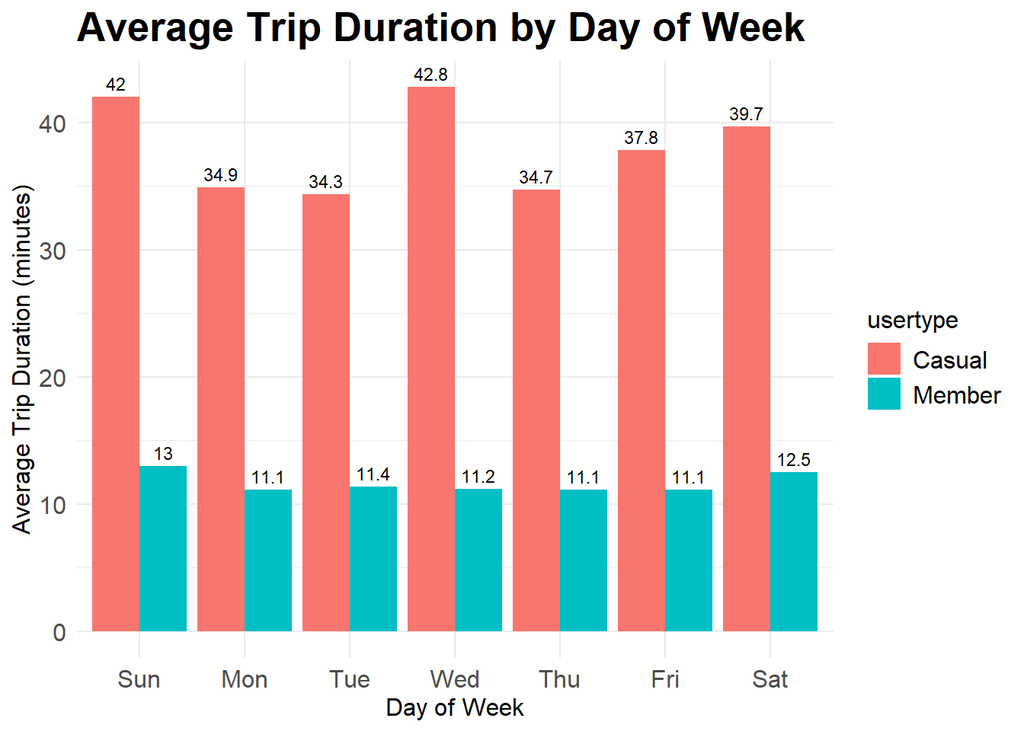

### 5.3 Comparing Daily Trip Counts by User Type

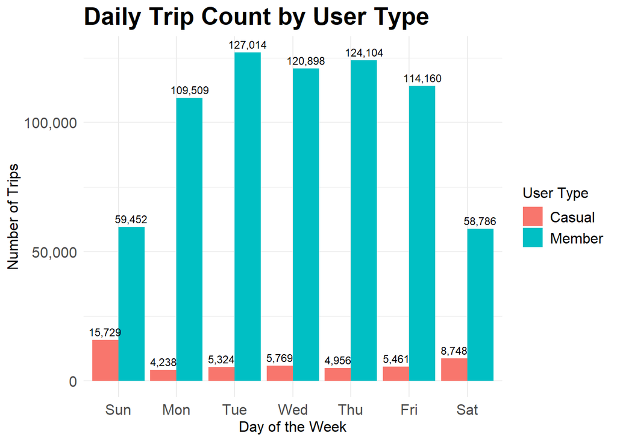

**Insight:**This clearly shows that casual users use bikes mainly during weekends and members use it mainly during weekdays, and overall use bikes the most.

To make a sense of it all we see a graph showing the average daytype trip count and the average trip duration by daytype to see the difference in count of trips and duration of trips between the two groups.

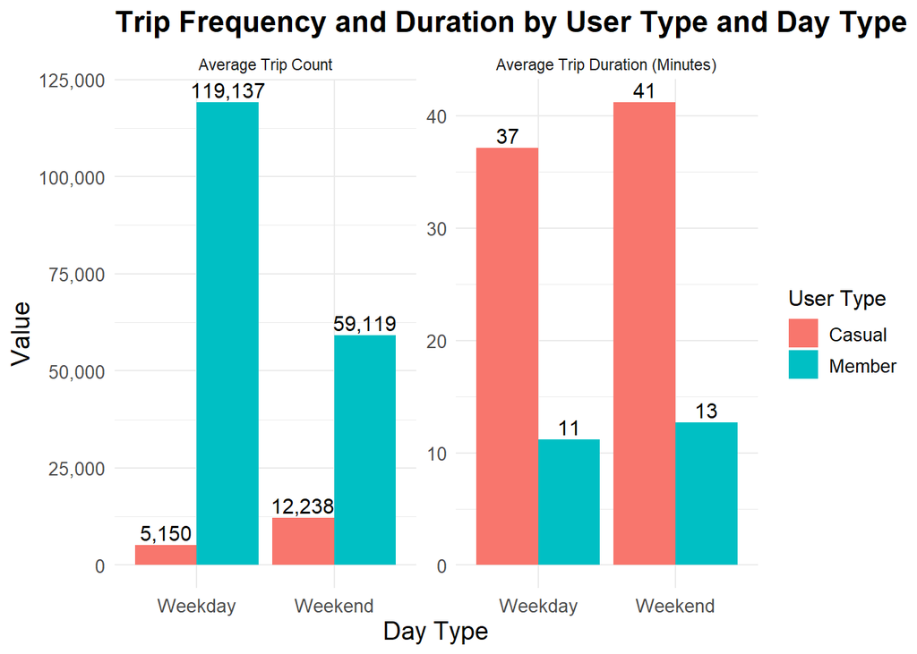

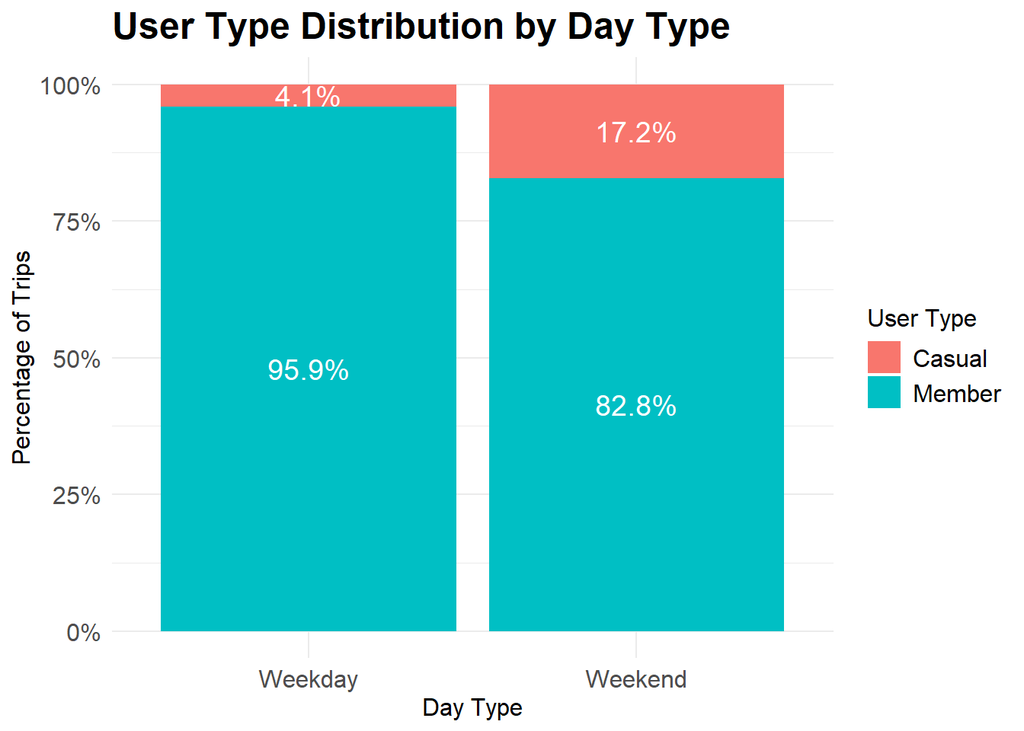

**Insight:** Casual users contribute 4.1% of total weekday trip counts, while members account for 95.9%. On weekends, casual users contribute 17.2% of total trip counts, while members account for 82.8%.

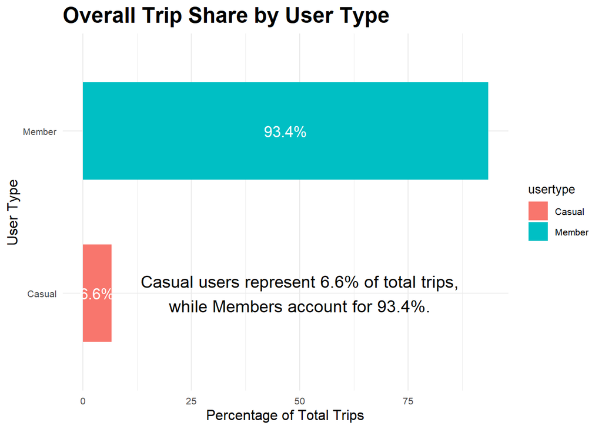

**Insight:** In general, casual users have a higher average trip duration than members. While this might initially seem beneficial, the financial team has evaluated other factors that affect total revenue. Longer trips do not necessarily translate into higher overall earnings. The company may instead prioritize consistent engagement, stable revenue, and long-term customer value. This is reflected in the data, as members contribute 93.4% of the total trip count, indicating that they drive the majority of system usage.

Next, we explore to see which time of the day the bikes are used the most to further see the behavioural difference between this users.

### 5.4 Comparing Hourly Ride Patterns by User Type

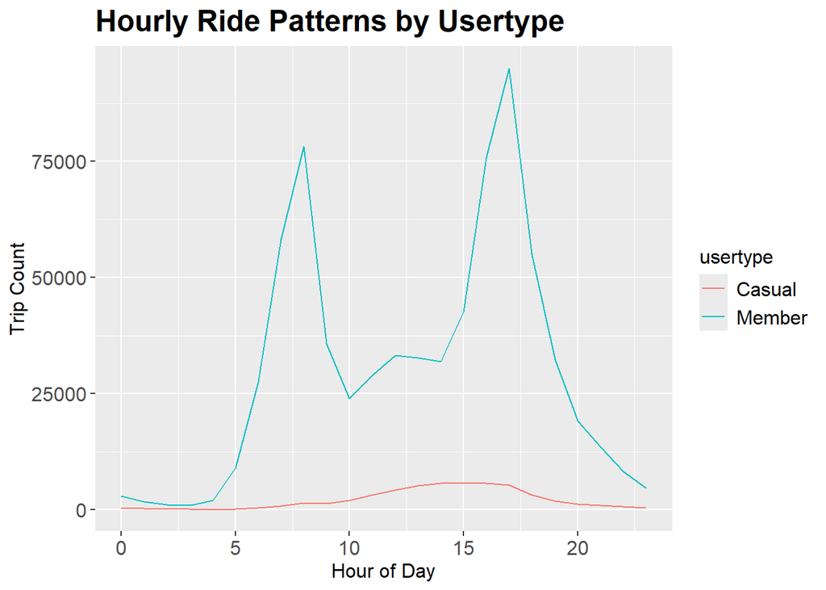

**Insight:** Members peak during morning and evening commute hours (7am – 9am, 4pm – 6pm), while casual riders peak in the afternoon, again, indicating leisure-based usage.

### 5.5 Popular Stations

Comparing Top Start Stations by User Type:

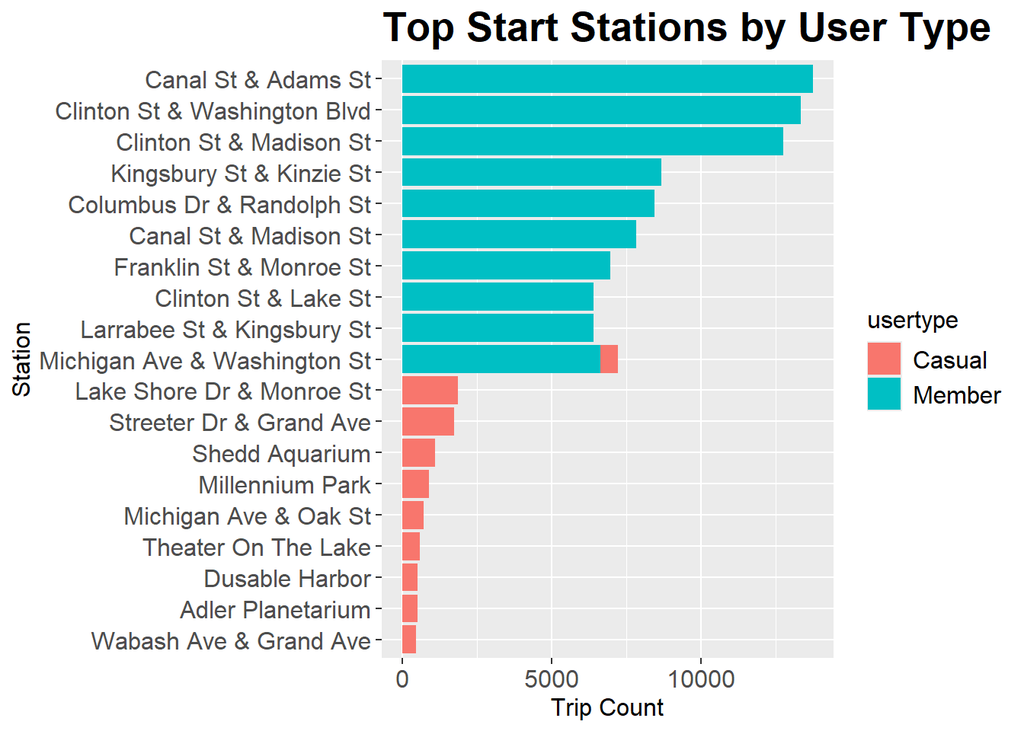

**Insight:** Members tend to start trips from central, commuter-friendly locations, while casual riders favor recreational or tourist-heavy stations.

## 6. Key Findings

- Casual riders take longer but fewer trips, particularly on weekends
- Members ride more frequently with shorter durations, especially on weekdays
- Members’ usage patterns align with commuting behaviour
- Casual riders’ behavior aligns with leisure and recreational use

## 7. Recommendations

### *Personalised and simplified data communication*

Cyclistic can analyse riders’ historical trip data to provide simple summaries showing:

- How long casual riders typically ride
- How much they spend on longer trips
- How this compares with what they would pay under a membership

Presenting this information in a clear and non-technical format can help casual riders better understand their own usage patterns. Cyclistic can use:

- In-app notifications
- App pop-ups after a completed ride
- Email summaries

These methods are cheaper, less aggressive, and more likely to be read at the right time.

#### Pros:

- Helps riders make informed decisions about membership
- Low cost and scalable communication method
- Timely notifications are more likely to be read and acted upon

#### Cons:

- Risk of overloading users with notifications, causing disengagement
- Some users may ignore messages entirely
- Requires accurate and up-to-date data processing

### *Encourage a one-month trial membership (not annual first)*

Since many casual riders believe they “don’t ride enough to sign up as an annual member”, Cyclistic should offer a one-month membership trial through in-app pop-ups and email notifications, using messages like *“Still doubting? Try it for one month and see for yourself”*. This lets users test the value of membership themselves.

After the one-month trial, Cyclistic can show users a comparison of:

- What they actually spent during the month
- What they would have spent without membership

#### Pros:

- Reduces hesitation for new members
- Lets users compare spending and decide based on real experience
- Builds trust and encourages long-term membership

#### Cons:

- Operational costs of managing trial memberships
- Messaging needs to be carefully timed to maximize uptake

### *Offer a discounted annual membership after the trial*

For riders who complete the trial period, Cyclistic can offer a discounted annual membership.

#### Pros:

- Targets users who already experienced the value, increasing conversion likelihood
- Rewards loyal trial users, enhancing brand perception
- Discounted offer incentivizes commitment without pressure

#### Cons:

- Discount reduces short-term revenue per user
- Risk that some users may only wait for discounts instead of paying full price

### *Target casual riders at the right time and place*

Since casual riders mostly ride on weekends and during specific daytime hours, Cyclistic can promote membership through:

- In-app notifications during peak casual riding hours
- Posters and QR codes, at high-traffic casual start stations
- App notifications shown near ride start and after ride completion

#### Pros:

- Reaches casual riders during peak usage hours, increasing message effectiveness
- Physical and digital presence reinforces brand visibility
- Increases likelihood of trial sign-ups and conversions

#### Cons:

- Marketing efforts may require extra resources (posters, QR codes, app scheduling)
- Messages may still be ignored if users are not receptive
- Over-targeting can feel intrusive if not carefully managed

## 8. Conclusion

Casual and member riders use Cyclistic bikes in fundamentally different ways. Casual riders take longer but fewer trips, particularly on weekends, while members ride more frequently with shorter durations, especially on weekdays. These patterns align with leisure use for casual riders and commuting behavior for members.

By leveraging these behavioral insights, Cyclistic can design targeted and realistic strategies to convert casual riders into loyal annual members. Recommended strategies include trial memberships, targeted notifications during peak casual riding hours, and promotions at high-traffic stations. Visualizations of peak ride times, trip durations, and start stations support these recommendations by highlighting when and where casual riders could be encouraged to try membership.

These insights provide actionable guidance for increasing membership uptake in order to drive sustainable growth and revenue stability for Cyclistic.

## 9. Limitations

- Data covers only Q1 2019 and Q1 2020; patterns may vary in other quarters
- Seasonal or weather effects are not captured
- No demographic data available
- Due to anonymized data, individual spending or exact membership savings could not be calculated. All insights are based on the observed behaviourial patterns from the data provided.